# Project 3

## Spectral Clustering using Andrew Ng's Algorithm

- On Spectral Clustering: Analysis and an algorithm by Andre Ng, etal.
- S = exp(-|x_i-x_j|^2 / 2*(sigma^2))
- D = diagonal matrix whose (i, i)-element is the sum of A's i-th row
- L = D^(-1/2)AD^(-1/2)
- FInd the k largest eigenvectors of L and normalized them into matrix X
- Treating X as new set of data, apply k-means clustering
- Based on the clustering result to cluster the original data

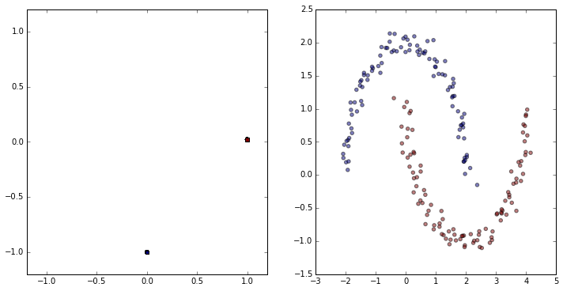

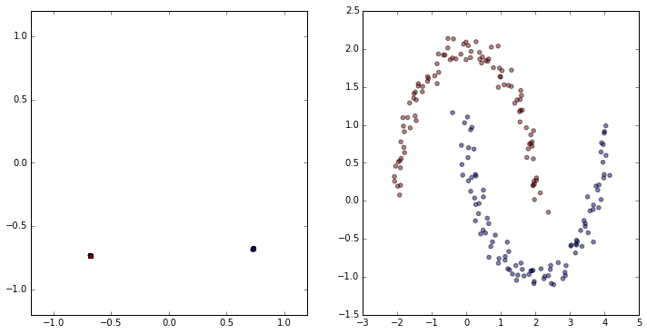

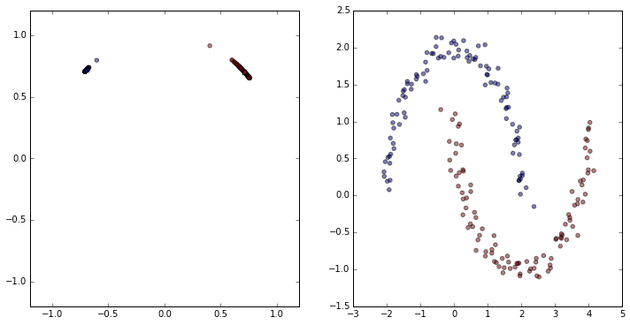

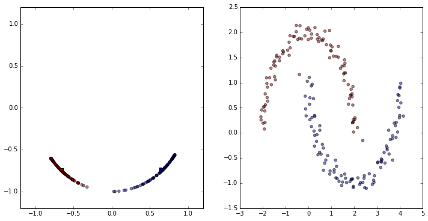

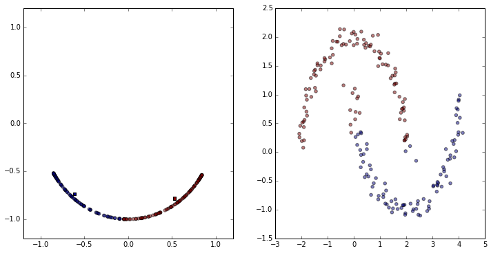

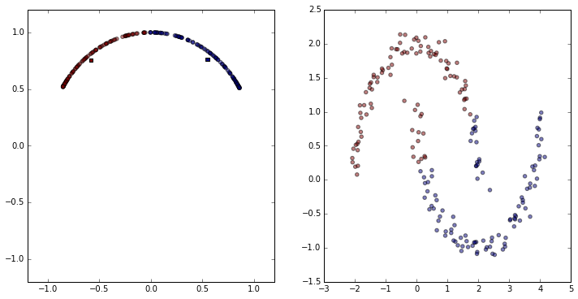

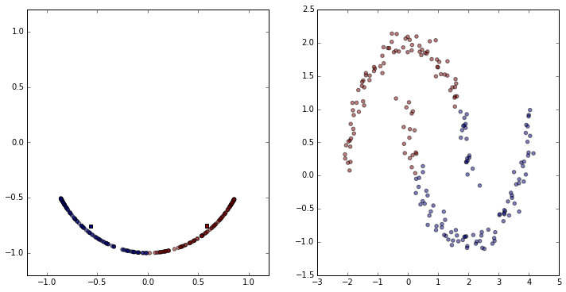

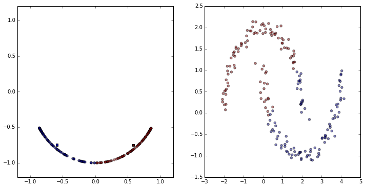

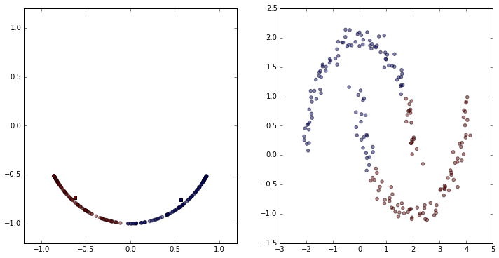

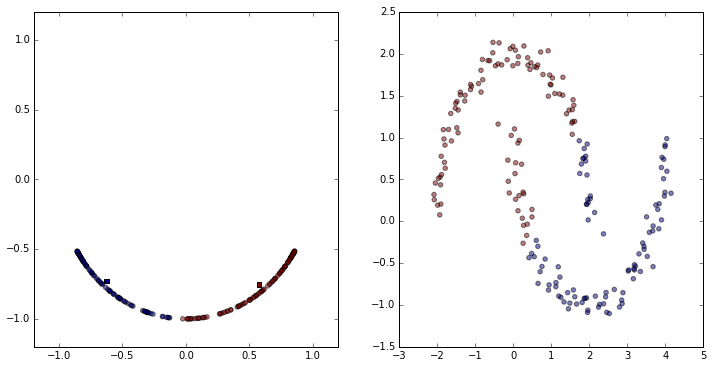

```python
scan_rex.demo1(my_data,2, 0.05, 1, 0.1)  #(my_data,k, sigma, start, end, step):
```

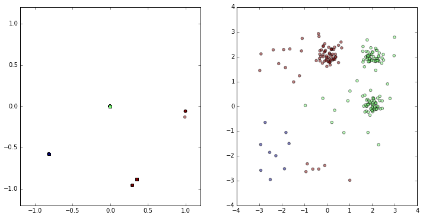

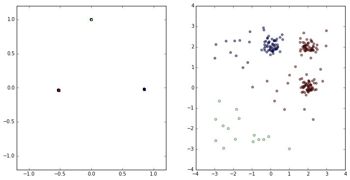

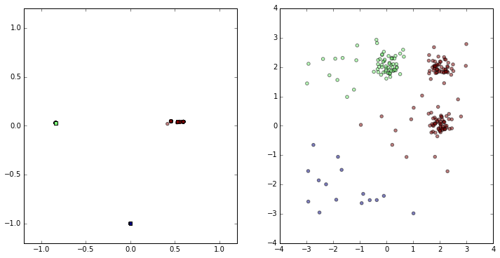

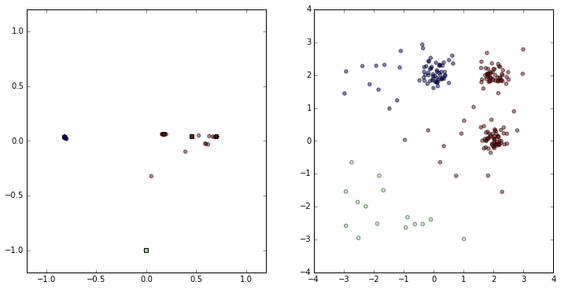

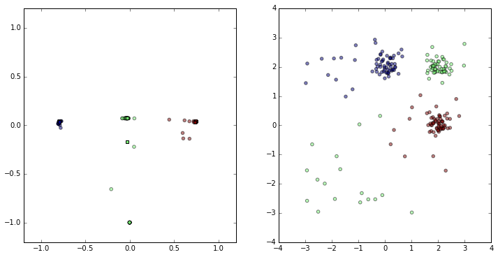

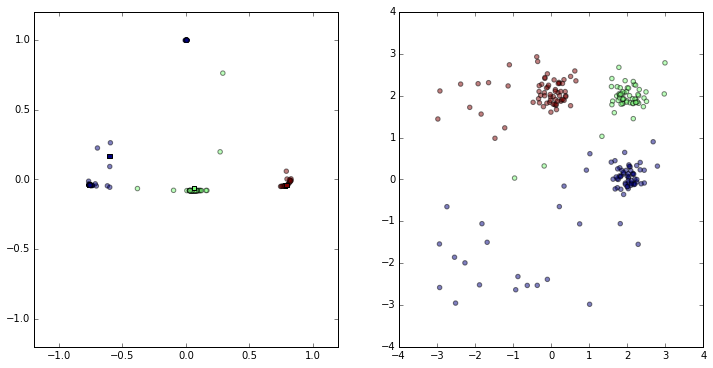

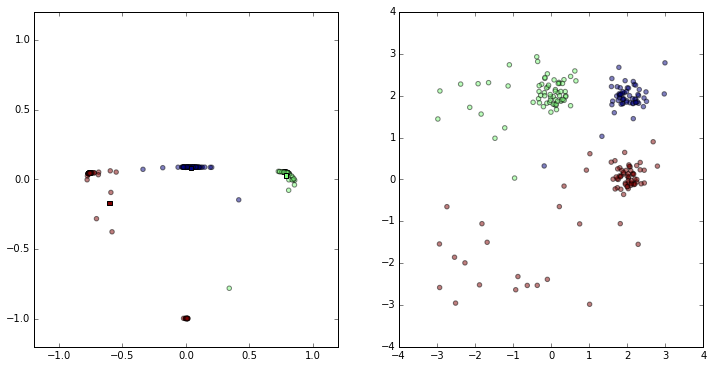

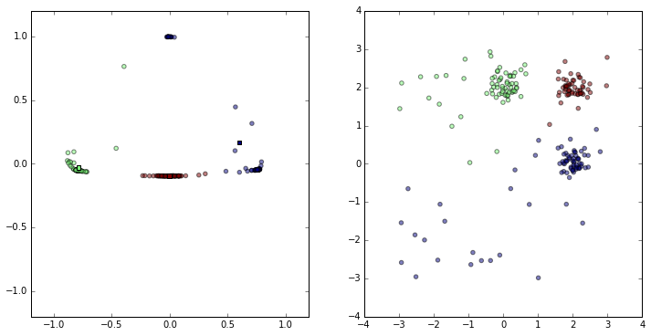

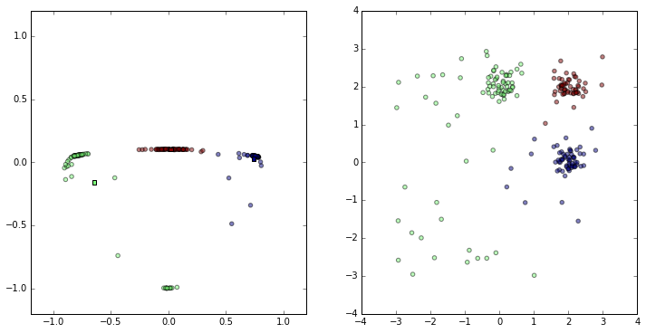

```python
scan_rex.demo1(mydata.T, 3, 0.1, 1, 0.1)  #(my_data,k, sigma, start, end, step):
```

### Shuffle the data order to see the result

- We would have same L on differnet odering of data
- As prediction, the resulting sigma would not change

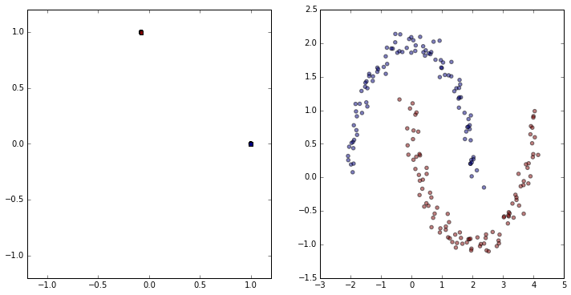

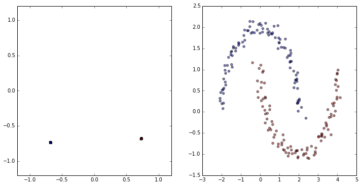

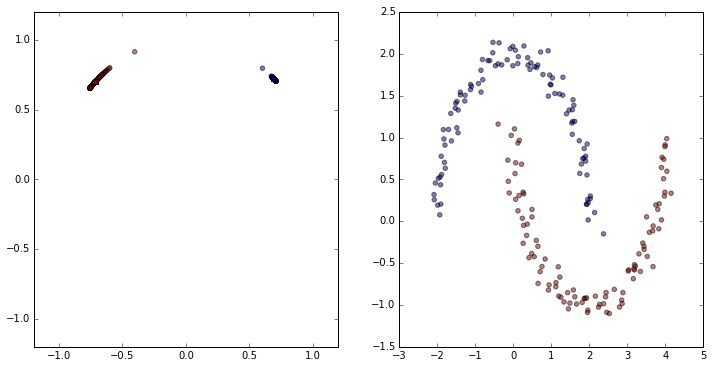

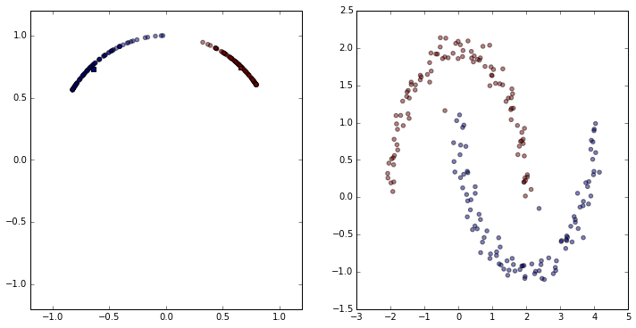

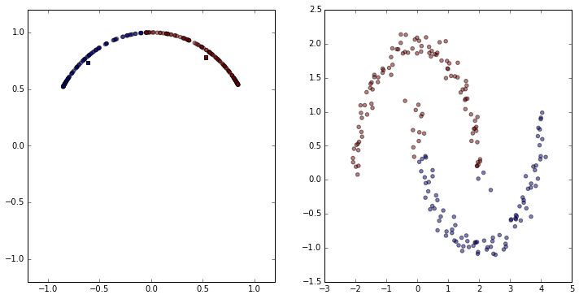

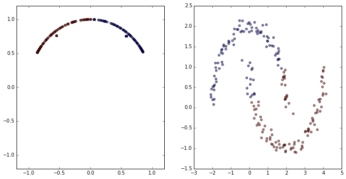

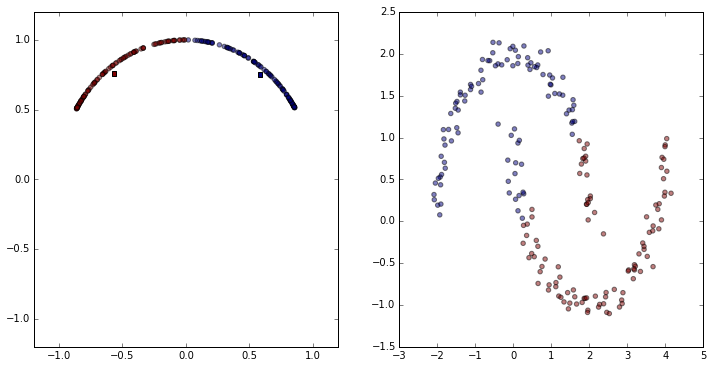

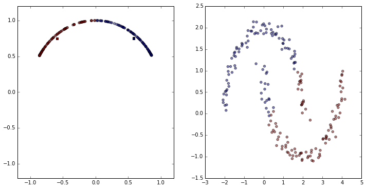

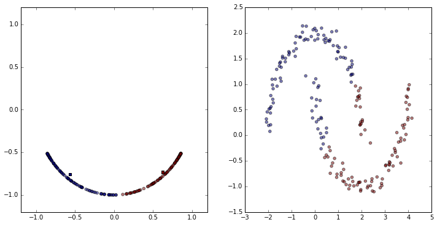

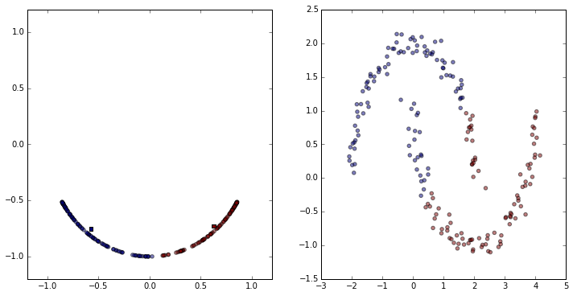

```python
idx = np.arange(0,200,1)
np.random.shuffle(idx)
scan_rex.demo1(my_data[:,idx],2, 0.05, 1, 0.1)  #(my_data,k, sigma, start, end, step):
```

## Discussion

- Even if the data is shuffled, the sigma to generate good clustering is stable.
- We could evaluate the result based on how tight the processed group is.
- It is easier to determine whether this Y is valid or not.

## Evaluate the tightness of Data

- Variance
- Support Vector Machine

## Task 3.3

### Dimensionality Reduction

```
# PCA ######################################
Found that choosing k as 2 will lead to at most error 59.310584579881876%

# LDA ######################################
Found 3 classes of 500 dimensional data
Class 1.0: 50 samples
Class 2.0: 50 samples
Class 3.0: 50 samples
Found that choosing k as 2 will lead to at most error -8019.271384515379%
```

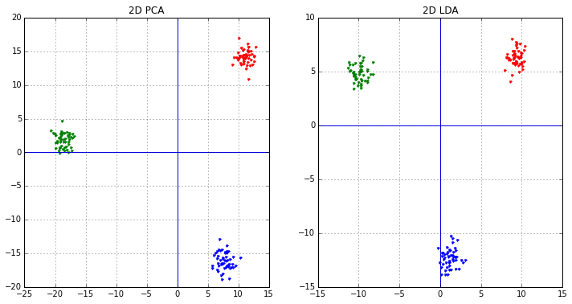

```python
res_pca, res_lda = demo_3(data_X, data_y, 2)
```

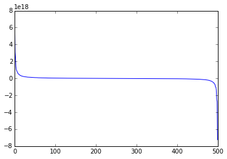

```python
evals = res_lda[-1][0]
plt.plot(evals)
```

```
# PCA ######################################
Found that choosing k as 2 will lead to at most error 59.310584579881876%

# LDA ######################################
Found 3 classes of 500 dimensional data
Class 1.0: 50 samples
Class 2.0: 50 samples
Class 3.0: 50 samples
Found that choosing k as 2 will lead to at most error 77.29489861745998%
```

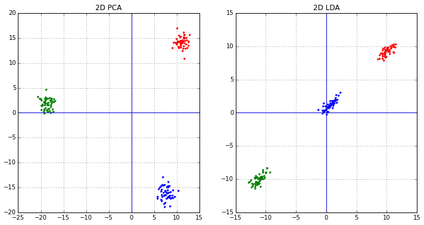

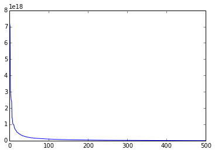

```python
res_pca, res_lda = demo_3(data_X, data_y, 2, use_abs_evals=True)
plt.figure()
plt.plot(res_lda[-1][0])
```

### Let's see for 3D

```
# PCA ######################################
Found that choosing k as 3 will lead to at most error 58.37033070345618%

# LDA ######################################
Found 3 classes of 500 dimensional data
Class 1.0: 50 samples
Class 2.0: 50 samples
Class 3.0: 50 samples
Found that choosing k as 3 will lead to at most error 72.36080941543305%
```

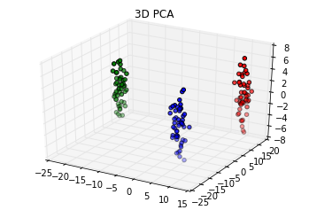

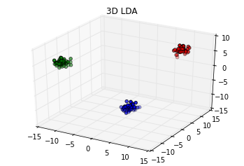

```python
res_pca, res_lda = demo_3(data_X, data_y, 3, use_abs_evals=True)
```

### Observations

- **PCA** finds the axes with maximum variance for the *whole* data
  - *unsupervised* algorithm
  - performs better for fewer samples per class
- **LDA** finds the axes for best separation *between* classes
  - *supervised* algorithm
- **Both** still have the underlying assumption of data having Gaussian Distribution

## Task 3.4

### Exploring Numerical Instabilities

### We all read the paper

In general, we expected:

- `method_1`
  - to give the best 10th degree polygon,
  - be fast,
  - not face issues
- `method_2`
  - to give okay result (conditionally)
  - be slow,
  - to face numerical issues
- `method_3`
  - to give a good 10th degree polygon,
  - be fast,
  - not face issues
- `method_4`
  - to give results a bit better than `method_2`
  - be the slowest (added transform step)
  - not face issues in this particular case (may be)

### Let's test the expectations!

```
/Users/myrmidon/.conda/envs/pattrex/lib/python3.4/site-packages/numpy/polynomial/polynomial.py:1383: RankWarning: The fit may be poorly conditioned
  warnings.warn(msg, pu.RankWarning)
```

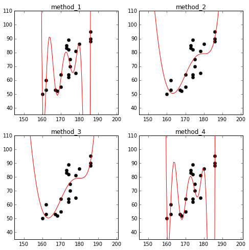

```python
def trsf(x, div=100):
      return x / div

n = 10

def method_1(hgt=hgt, wgt=wgt, n=n, x=x):
    # regression using ployfit
    c = poly.polyfit(hgt, wgt, n)
    y = poly.polyval(x, c)
    return c, y

def method_2(hgt=hgt, wgt=wgt, n=n, x=x):
    # regression using the Vandermonde matrix and pinv
    X = poly.polyvander(hgt, n)
    c = np.dot(la.pinv(X), wgt)
    y = np.dot(poly.polyvander(x,n), c)
    return c, y

def method_3(hgt=hgt, wgt=wgt, n=n, x=x):
    # regression using the Vandermonde matrix and lstsq
    X = poly.polyvander(hgt, n)
    c = la.lstsq(X, wgt)[0]
    y = np.dot(poly.polyvander(x,n), c)
    return c, y

def method_4(hgt=hgt, wgt=wgt, n=n, x=x, div=100):
    # regression on transformed data using the Vandermonde
    #    matrix and pinv
    X = poly.polyvander(trsf(hgt, div=div), n)
    c = np.dot(la.pinv(X), wgt)
    y = np.dot(poly.polyvander(trsf(x, div=div),n), c)
    return c, y

demo_4_plot([m()[1] for m in [method_1, method_2, method_3, method_4]],
            [m for m in ["method_1", "method_2", "method_3", "method_4"]])
```

### What happend?

- Warning raised by polyfit
  - **abdullah:** it is actually helpful
- `method_4` gives almost as 'good' a result as `method_1`
  - **can:** the `trsf` function is scaling the values by 1/100
  - **cifong:** problems with raising $10^2$ values to powers of 10 might be getting resolved
  - **abdullah:** actually, no. Look at the coefficients. All are of order $10^{10}$

```python
coeffs = np.array([m()[0] for m in [method_1, method_2, method_3, method_4]])
print(coeffs.T)
```

```
[[  9.94143754e+11   3.39741629e-19   3.39741629e-19   5.01564415e+11]
 [ -3.61297680e+10   1.17900058e-11   1.17900058e-11  -1.40808912e+12]
 [  5.01765490e+08  -9.63490518e-15  -9.63490518e-15   9.77502398e+11]
 [ -2.82817017e+06   2.89518900e-13   2.89518900e-13   7.51115288e+11]
 [ -1.94892561e+03   2.13966507e-11   2.13966507e-11  -1.10264539e+12]
 [  9.06665686e+01   1.23047796e-09   1.23047796e-09  -3.67718543e+11]
 [ -1.48086662e-01   4.24710787e-08   4.24710787e-08   1.39301069e+12]
 [ -2.67679787e-03  -9.78013259e-10  -9.78013259e-10  -1.08608618e+12]
 [  1.75196332e-05   8.43625378e-12   8.43625378e-12   4.20281052e+11]
 [ -4.38544409e-08  -3.23109114e-14  -3.23109114e-14  -8.41040291e+10]
 [  4.13603892e-11   4.63624155e-17   4.63624155e-17   6.97330421e+09]]
```

- **umut:** Let's Time them

```python
%timeit method_1()
%timeit method_2()
%timeit method_3()
%timeit method_4()
```

```
1000 loops, best of 3: 234 µs per loop
10000 loops, best of 3: 162 µs per loop
10000 loops, best of 3: 164 µs per loop
1000 loops, best of 3: 174 µs per loop
```

- **abdullah:** the dataset is too small. Run again with 1000 copies
  - it is still in milliseconds
  - **can:** don't go above 100,000

```python
hgt_11 = np.tile(hgt, (1000))
wgt_11 = np.tile(wgt, (1000))
print(hgt_11.shape[0])

%timeit method_1(hgt_11, wgt_11)
%timeit method_2(hgt_11, wgt_11)
%timeit method_3(hgt_11, wgt_11)
%timeit method_4(hgt_11, wgt_11)
```

```
21000
100 loops, best of 3: 4.36 ms per loop
100 loops, best of 3: 7.87 ms per loop
100 loops, best of 3: 3.22 ms per loop
100 loops, best of 3: 7.92 ms per loop
```

- **cifong:** Let me dive into the transformation

### How do results change for `method_4` for different divisors

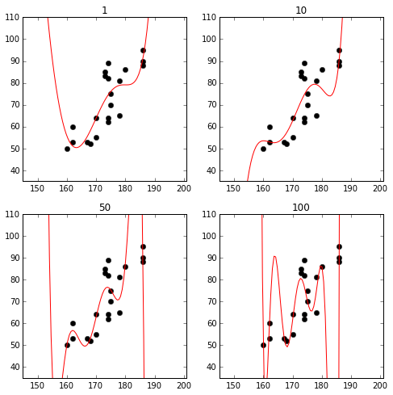

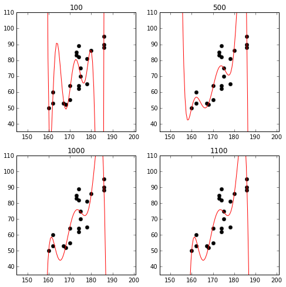

```python
ys = []
for d in [1, 10, 50, 100]:
    ys.append(method_4(div=d)[1])

demo_4_plot(ys, [1, 10, 50, 100])
ys = []
for d in [100, 500, 1000, 1100]:
    ys.append(method_4(div=d)[1])

demo_4_plot(ys, [100, 500, 1000, 1100])
```

## The fitting dimention went up as the divisor goes up,

- The value in given data is 3 digit decimal,
- divisor = 100 make the value to 1 digit

## Floating point issue in Python

- By Python Documentation
- 0.1(decimal) is presented as
- 0.00011001100110011001100110011001100110011001100110011010(Binary)
- Print (0.1)
- 0.1000000000000000055511151231257827021181583404541015625
- https://docs.python.org/2/tutorial/floatingpoint.html

```python
print(np.finfo(np.float32))
print(np.finfo(np.float64))
```

```
Machine parameters for float32
---------------------------------------------------------------------
precision=  6   resolution= 1.0000000e-06
machep=   -23   eps=        1.1920929e-07
negep =   -24   epsneg=     5.9604645e-08
minexp=  -126   tiny=       1.1754944e-38
maxexp=   128   max=        3.4028235e+38
nexp  =     8   min=        -max
---------------------------------------------------------------------

Machine parameters for float64
---------------------------------------------------------------------
precision= 15   resolution= 1.0000000000000001e-15
machep=   -52   eps=        2.2204460492503131e-16
negep =   -53   epsneg=     1.1102230246251565e-16
minexp= -1022   tiny=       2.2250738585072014e-308
maxexp=  1024   max=        1.7976931348623157e+308
nexp  =    11   min=        -max
---------------------------------------------------------------------
```

## Looking in to `numpy.linalg.pinv`

- `numpy.linalg.pinv(a, rcond=1e-15)`
- `rcond` is the precision of float 64, which `linalg` supports
- we found this code inside

```python
a, wrap = _makearray(a)
_assertNoEmpty2d(a)
a = a.conjugate()
u, s, vt = svd(a, 0)
m = u.shape[0]
n = vt.shape[1]
cutoff = rcond*maximum.reduce(s)
for i in range(min(n, m)):
    if s[i] > cutoff:           #Suspicious part, set value to zero
        s[i] = 1./s[i]
    else:
        s[i] = 0.;
res = dot(transpose(vt), multiply(s[:, newaxis], transpose(u)))
return wrap(res)
```

## Test this part

- See how many cutsin different divisor

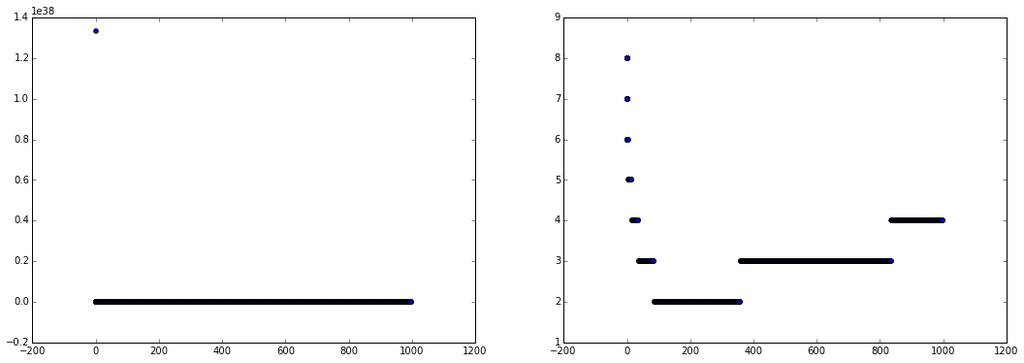

```python
count = []
cutoffValue = []
inteNI = np.arange(0.001,1,0.001)
intePI = np.arange(1,1000,1)
divisor = np.append(inteNI, intePI)
for i in divisor:
    X = poly.polyvander(trsf(hgt,i), n)
    cutCount, cutoff = countPinvCutoff(X)
    list.append(count, cutCount)
    list.append(cutoffValue, cutoff)

fig = plt.figure(figsize=(18, 6))
plt.subplot(121)
plt.scatter(divisor, cutoffValue)
plt.subplot(122)
plt.scatter(divisor, count)
```

## Discussion

- 1.Ther trend mathes the degeneration of fitting function that
- the lower the cut off, the higher remaining dimension we have
- 2.We would have at least 2 cutoffs in all divisor

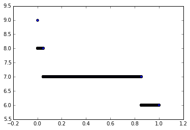

```python
count = []
for i in np.arange(0.0001,1,0.0001):
    X = poly.polyvander(trsf(hgt,i), n)
    count.append(countPinvCutoff(X)[0])

plt.scatter(np.arange(0.0001,1,0.0001), count)
```

## Plot some divisors on 3 variants

- Compare with the tolerence = epslon *max(m,n)* maximum(s)
- linalg.inv cutoff = epslon * maximum(s)
- No cut off

```
divisor: 0.0100, tolerence: 279582202827253860620707037184.0000000000000000, tolCount: 8, cutoff:13313438229869231143982727168.0000000000000000, CoCount: 8
```

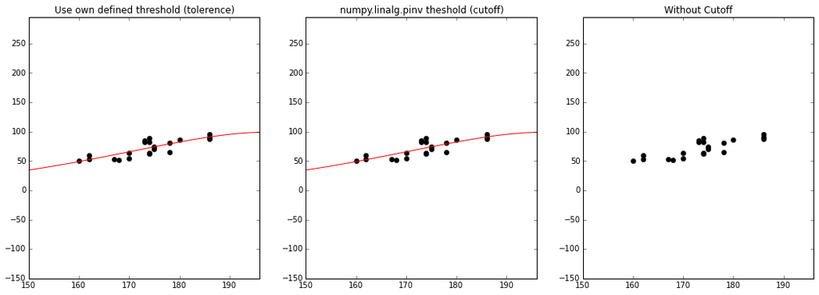

```
divisor: 0.0500, tolerence: 28629218642458107183104.0000000000000000, tolCount: 8, cutoff:1363296125831338524672.0000000000000000, CoCount: 7
```

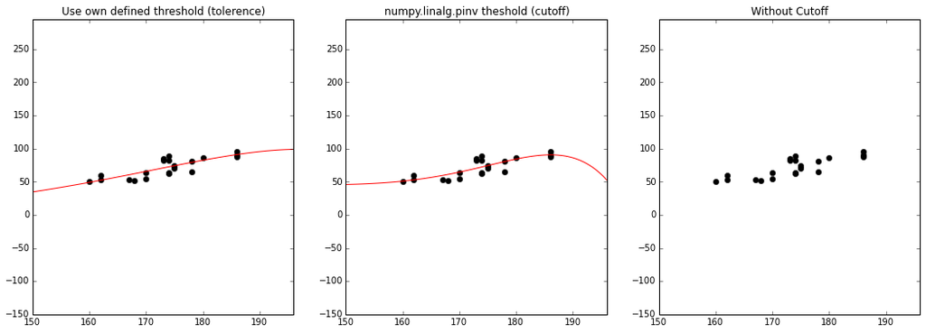

```
divisor: 0.1000, tolerence: 27958224604901580800.0000000000000000, tolCount: 8, cutoff:1331344028804837376.0000000000000000, CoCount: 7
```

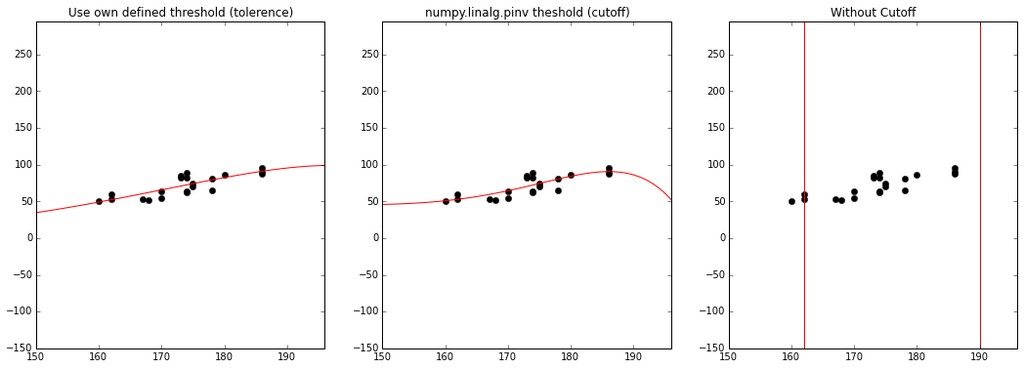

```
divisor: 0.5000, tolerence: 2862932929080.0292968750000000, tolCount: 7, cutoff:136330139480.0014038085937500, CoCount: 7
```

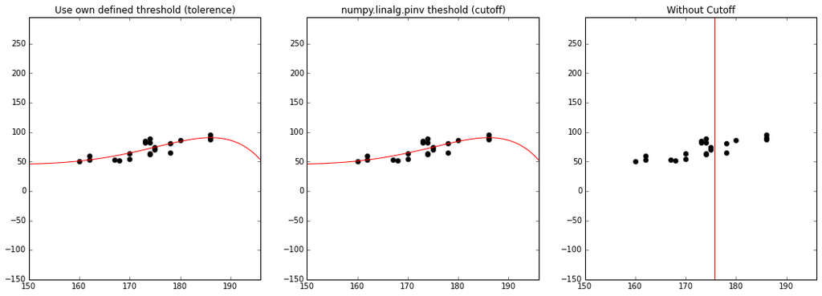

```
divisor: 1.0000, tolerence: 2795865683.2700839042663574, tolCount: 7, cutoff:133136461.1080992370843887, CoCount: 6
```

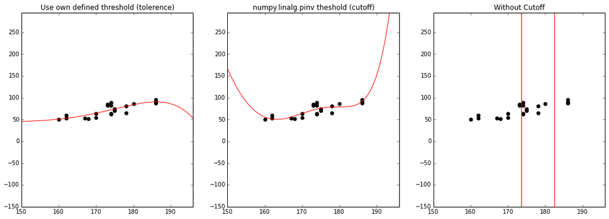

```
divisor: 5.0000, tolerence: 286.4040064468964601, tolCount: 6, cutoff:13.6382860212807824, CoCount: 5
```

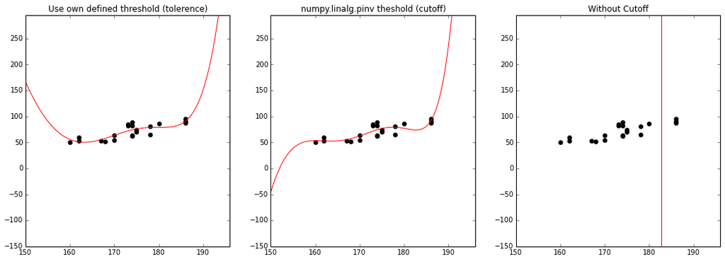

```
divisor: 10.0000, tolerence: 0.2800198168618731, tolCount: 5, cutoff:0.0133342769934225, CoCount: 5
```

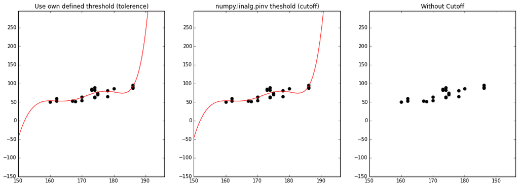

```
divisor: 50.0000, tolerence: 0.0000000298173451, tolCount: 4, cutoff:0.0000000014198736, CoCount: 3
```

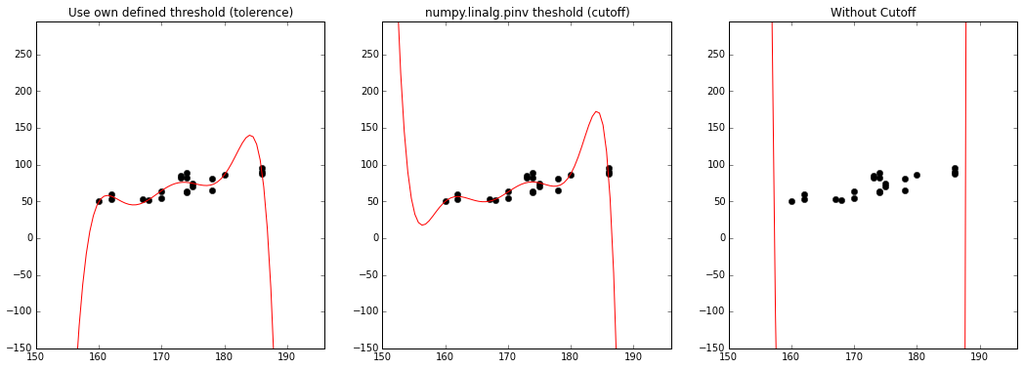

```
divisor: 100.0000, tolerence: 0.0000000000337292, tolCount: 3, cutoff:0.0000000000016062, CoCount: 2
```

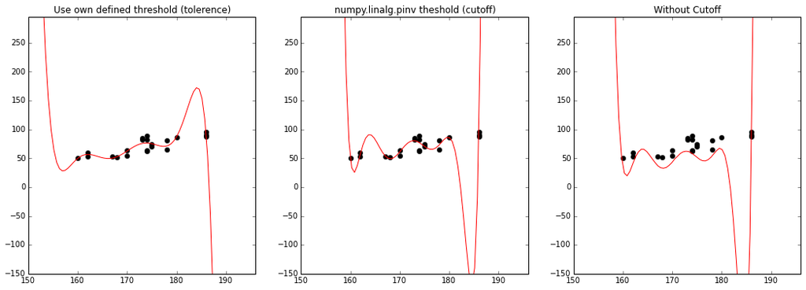

```
divisor: 500.0000, tolerence: 0.0000000000001026, tolCount: 3, cutoff:0.0000000000000049, CoCount: 3
```

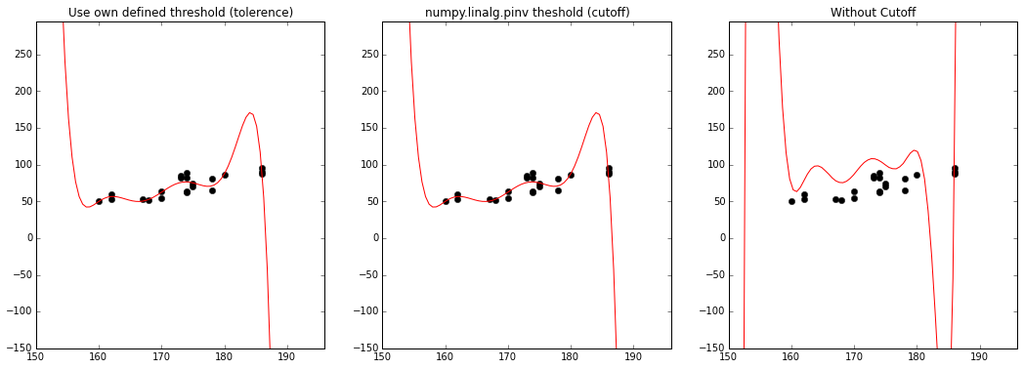

```
divisor: 1000.0000, tolerence: 0.0000000000000977, tolCount: 4, cutoff:0.0000000000000047, CoCount: 4
```

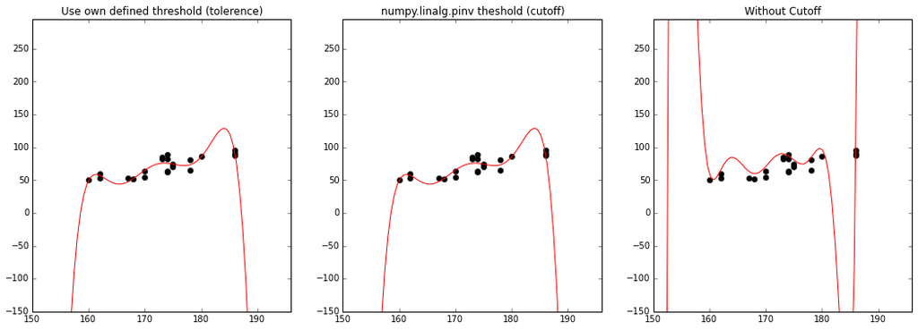

```python
index = [0.01,0.05,0.1,0.5, 1,5, 10, 50, 100, 500, 1000]
for i in index:
    demoPic(i)
```

## References

- Slides
- C. Bauckhage. Lecture Notes on Data Science: k-Means Clustering
- C. Bauckhage. Lecture Notes on Data Science: Online k-Means Clustering
- Andre Ng, etal On Spectral Clustering: Analysis and an algorithm
- A.M. Martinez et al. PCA vs. LDA